# National Weather Service Storm Data Analysis - Most Damaging Event Types

## Synopsis

The data is analysed by firstly reading it into R as a data frame. To enable analysis of the damage to human health, the dataframe is summarised by Event type to calculate the total damage by each event type. Datapoints with comparitively little damage are then filtered out of the dataset to make the final plots more readable. A metric for the total damage to human health (fatalities + injuries) is also calculated with a weighting such that a fatality is worth twice as much as a injury. The total financial damage is calculated by first expanding the data (i.e. 2.5 and k becomes 2500) before summarising it in a similar way to the human health data. In this case the metric for total damage is simply the sum of the property and crop damage. Both datasets are also melted before plotting to make it easier to use plotting libraries (in this case ggplot2). Also, the datasets are arranged in descending order of total damage to make it easier to visualise the data when it is presented in a tabular format.

## Data Processing

Loads the needed libraries

```r
library(dplyr)
```

```r
library(ggplot2)
library(reshape2)
```

Downloads and Reads the dataset into R.

```r
download.file("https://d396qusza40orc.cloudfront.net/repdata%2Fdata%2FStormData.csv.bz2", "data.csv.bz2")
rawData <- read.csv("data.csv.bz2")
rawData <- rawData %>% group_by(EVTYPE)
```

```r
summarisedData <- rawData %>% group_by(EVTYPE) %>% summarise(totalFatalities = sum(FATALITIES), totalInjuries = sum(INJURIES))
humanDamageData <- summarisedData %>% filter(totalFatalities>10, totalInjuries>10)
```

Attempts to estimate the total damage to human health as a function of the totalFatilities and totalInjuries. I chose to weight them such that a fatality is worth twice as much as an injury.

```r
humanDamageData <- humanDamageData %>% mutate(totalHumanDamage = 2*totalFatalities + totalInjuries) %>%
  arrange(desc(totalHumanDamage))
```

Calculates the total property and crop damage using the PROPDMGEXP column before filtering datapoints with low values to make the plot more readable

```r
propDamageData <- rawData %>% mutate(completePropDamage = ifelse(tolower(PROPDMGEXP)=="k",PROPDMG*1000,ifelse(tolower(PROPDMGEXP)=="m", PROPDMG*1000000, ifelse(tolower(PROPDMGEXP)=="b",PROPDMG*1000000000,PROPDMG)))) %>%
  mutate(completeCropDamage = ifelse(tolower(CROPDMGEXP)=="k",CROPDMG*1000,ifelse(tolower(CROPDMGEXP)=="m", CROPDMG*1000000, ifelse(tolower(CROPDMGEXP)=="b",CROPDMG*1000000000,CROPDMG)))) %>%
  select(EVTYPE, completePropDamage, completeCropDamage) %>%
  mutate(totalDamage=completePropDamage+completeCropDamage) %>%
  filter(completePropDamage>1000000, completeCropDamage>1000000)

propDamageData <- propDamageData %>% group_by(EVTYPE) %>%
  summarise(totalPropDamage=sum(completePropDamage), totalCropDamage=sum(completeCropDamage), totalDamage=sum(totalDamage))
```

## Results

#### Damage to Human Life

Plots only the fatality and injury data to help visualise any overall trends.

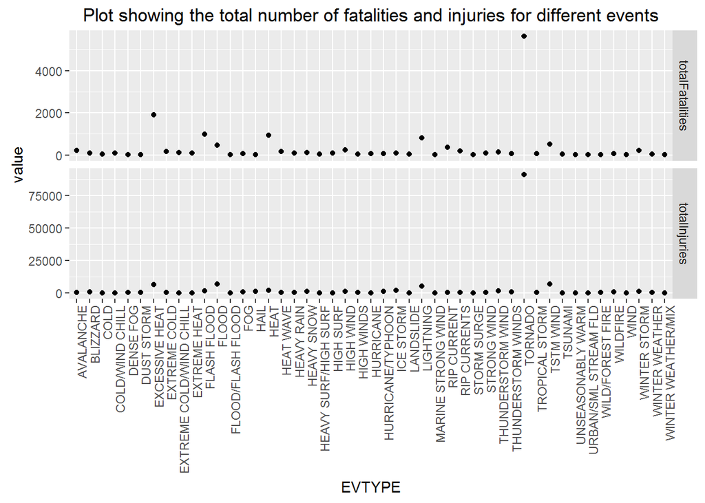

```r
## Melts the data to make it a long dataset (which can be plotted in ggplot2)
fatalityAndInjuryData <- melt(humanDamageData %>% select(EVTYPE, totalFatalities, totalInjuries), id="EVTYPE")
g <- ggplot(fatalityAndInjuryData, aes(EVTYPE, value)) +
  facet_grid(variable~., scales="free") +
  geom_point() +
  theme(axis.text.x = element_text(angle=90, hjust=1)) +
  ggtitle("Plot showing the total number of fatalities and injuries for different events")
print(g)
```

Plots the eariler calculated metric for total human health damage. This helps to visualise the data from the 2 earlier plots and any trends between them.

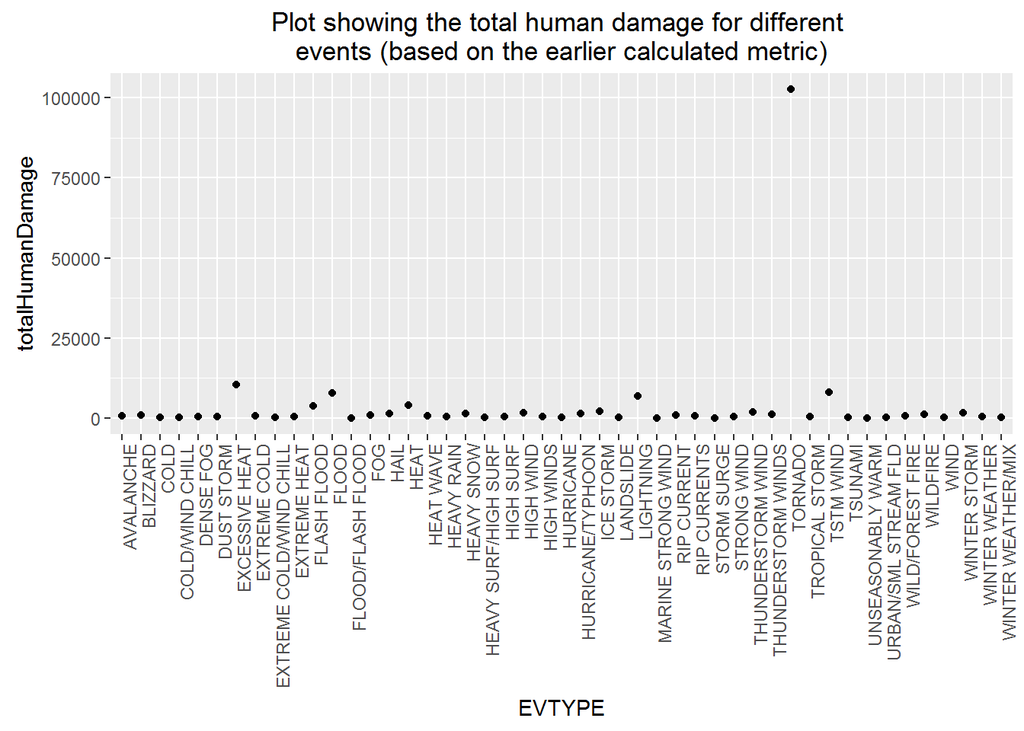

```r
g <- ggplot(humanDamageData, aes(EVTYPE, totalHumanDamage)) +
  geom_point() +
  theme(axis.text.x = element_text(angle=90, hjust=1)) +
  ggtitle("Plot showing the total human damage for different \nevents (based on the earlier calculated metric)")
print(g)
```

Displays the 10 events which are most damaging to human health to help inform any decision making (by providing precise information)

```r
head(arrange(humanDamageData, desc(totalHumanDamage)), 10)
```

```
## # A tibble: 10 × 4
##               EVTYPE totalFatalities totalInjuries totalHumanDamage
##               <fctr>           <dbl>         <dbl>            <dbl>
## 1            TORNADO            5633         91346           102612
## 2     EXCESSIVE HEAT            1903          6525            10331
## 3          TSTM WIND             504          6957             7965
## 4              FLOOD             470          6789             7729
## 5          LIGHTNING             816          5230             6862
## 6               HEAT             937          2100             3974
## 7        FLASH FLOOD             978          1777             3733
## 8          ICE STORM              89          1975             2153
## 9  THUNDERSTORM WIND             133          1488             1754
## 10      WINTER STORM             206          1321             1733
```

#### Property Damage

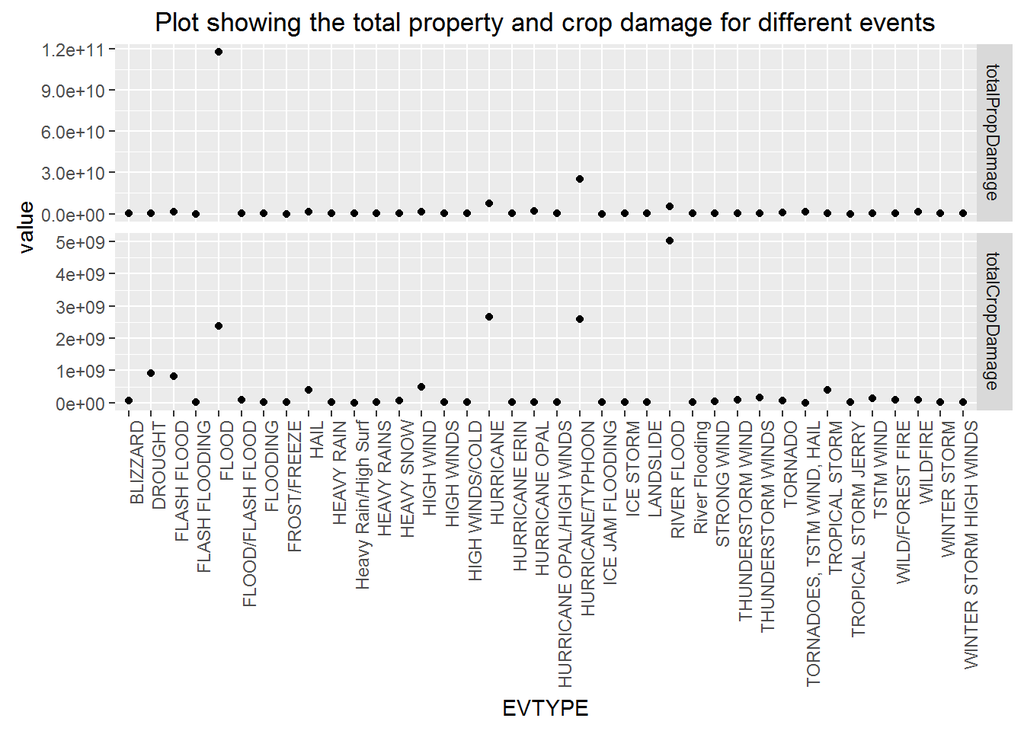

```r
##Melts the data to make it a long dataset (which can be plotted in ggplot2)
meltedDamageData <- melt(propDamageData %>% select(-totalDamage), id="EVTYPE")
g <- ggplot(meltedDamageData, aes(EVTYPE, value)) +
  facet_grid(variable~., scales="free") +
  geom_point() +
  theme(axis.text.x = element_text(angle=90, hjust=1)) +
  ggtitle("Plot showing the total property and crop damage for different events")
print(g)
```

Displays the 10 events which cause the most overall financial impact to help inform any decision making (by providing precise information)

```r
head(arrange(propDamageData, desc(totalDamage), desc(totalPropDamage), desc(totalCropDamage)),10)
```

```
## # A tibble: 10 × 4
##                        EVTYPE totalPropDamage totalCropDamage  totalDamage
##                        <fctr>           <dbl>           <dbl>        <dbl>
## 1                       FLOOD    117668720000      2368860000 120037580000
## 2           HURRICANE/TYPHOON     25073720000      2593840000  27667560000
## 3                   HURRICANE      7586870000      2658510000  10245380000
## 4                 RIVER FLOOD      5022800000      5019000000  10041800000
## 5              HURRICANE OPAL      2168000000        19000000   2187000000
## 6                 FLASH FLOOD      1359230000       816510000   2175740000
## 7                        HAIL      1247370000       400800000   1648170000
## 8                   HIGH WIND      1140390000       478500000   1618890000
## 9  TORNADOES, TSTM WIND, HAIL      1600000000         2500000   1602500000
## 10                   WILDFIRE      1296220000        88900000   1385120000
```